# The Effect of Quality of Sleep and Gender on Sleep Disorders

## 4.2 Regularization path with Logistic Regression (LASSO)

This plot visualizes the change in logistic regression coefficients as regularization strength increases towards the right. Each colored line represents one predictor’s coefficient path.

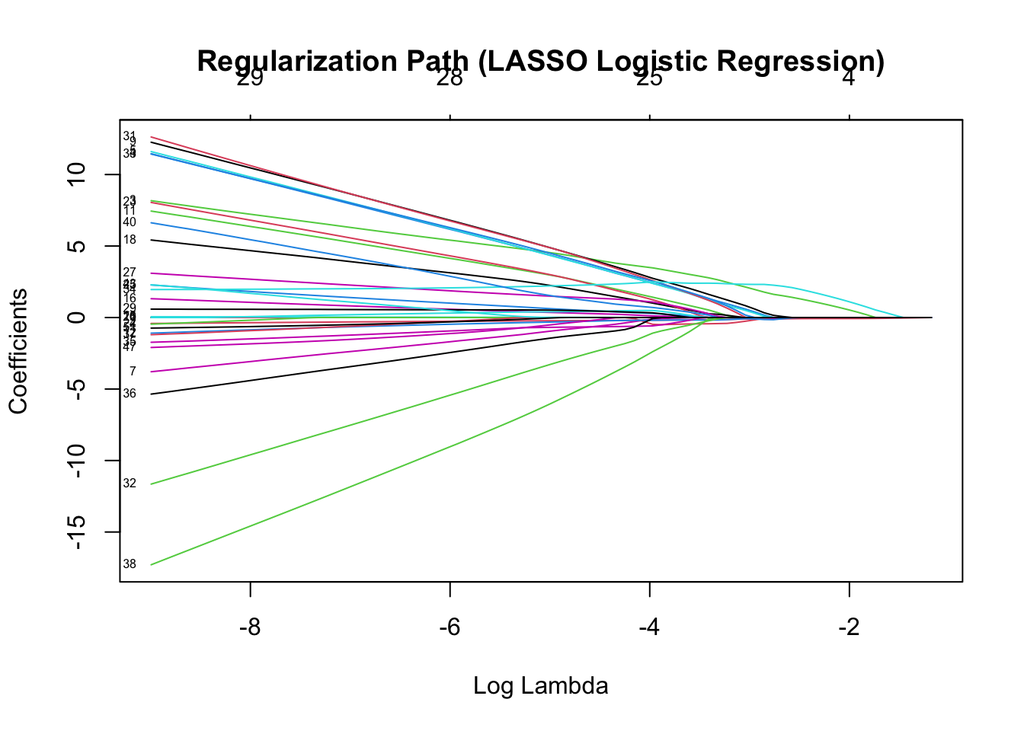

```r
train_control <- trainControl(method = "cv", number = 10, classProbs = TRUE, summaryFunction = twoClassSummary)

model_lasso <- train(
  Gender ~ .,
  data = train_data,
  method = "glmnet",
  trControl = train_control,
  tuneGrid = expand.grid(alpha = 1, lambda = seq(0.0001, 1, length = 100)),
  metric = "ROC",
  family = "binomial"
)

plot(model_lasso$finalModel, xvar = "lambda", label = TRUE)
title("Regularization Path (LASSO Logistic Regression)")
```

As you move from left to right (log lamba) increases: the coefficients gradually shrink towards zero, showing the effect of LASSO penalty. Lines flatten at zero means the predictors are excluded from the model which helps in automatically selecting important features by shrinking irrelevant variables to zero.

# 5 Part II SVM

In this section, we extend our predictive modeling effects by applying Support Vector Machines (SVM) to both regression and classification tasks using the same cleaned and feature engineered dataset from before. We apply SVM models to evaluate whether SVM models offer improvemnts in predictive performance over regularized regression models to interpret behavior in context of sleep health and lifestyle factors.

## 5.1 Data Preparation

Before modeling can begin, the dataset was cleaned and transformed to ensure consistency and compatibility. Binary filtering for gender was done. Gender was converted to a factor variable for use in classification models. Missing values were removed. Blood Pressure column was split into two numeric columns: Systolic and Diastolic. A stratified split was applied using 70/30 for training and testing data. The variable Occupation was standardized to have identical factor levels in both training and test sets to prevent errors in prediction.

```r
sleep_clean <- sleep %>%
  filter(Gender %in% c("Male", "Female")) %>%
  mutate(Gender = factor(Gender)) %>%
  drop_na()

# Split Blood.Pressure into systolic and diastolic
sleep_clean <- sleep_clean %>%
  separate(Blood.Pressure, into = c("Systolic", "Diastolic"), sep = "/", convert = TRUE)

# Confirm conversion
#str(sleep_clean[, c("Systolic", "Diastolic")])

# 70/30 train-test split
set.seed(123)
index <- sample(1:nrow(sleep_clean), 0.7 * nrow(sleep_clean))
train.data <- sleep_clean[index, ]
test.data  <- sleep_clean[-index, ]
combined_levels <- union(levels(factor(train.data$Occupation)), levels(factor(test.data$Occupation)))
#set.seed(123)
split_idx <- caret::createDataPartition(sleep_clean$Gender, p = 0.7, list = FALSE)
train.data <- sleep_clean[split_idx, ]
test.data  <- sleep_clean[-split_idx, ]

train.data$Occupation <- factor(train.data$Occupation, levels = combined_levels)
test.data$Occupation  <- factor(test.data$Occupation, levels = combined_levels)
```

## 5.2 Hyperparameter Tuning (RBF Kernel)

Grid search hyperparameter using 5 fold cross validation was performed to opitmize the performance of Support Vector Machine(SVM). The parameters tuned were: Cost: which controls the trade-off between maximizing the margin and minimizing classification error. Gamma: used to define how far the influence of a single training example reaches.

```r
tune_control <- tune.control(cross = 5, nrepeat = 1)

tune.RBF <- tune(
  svm,
  Gender ~ .,
  data = train.data,
  kernel = "radial",
  ranges = list(
    cost = 10^(-1:2),
    gamma = c(0.1, 0.5, 1, 2)
  ),
  tunecontrol = tune_control
)

# Best model
best.RBF <- tune.RBF$best.model
best.cost.RBF <- best.RBF$cost
best.gamma.RBF <- best.RBF$gamma
```

## 5.3 Final Model Training

Using the best cost and gamma values obtained above, the final SVM classfier was trained with the RBF Kernal on the full training dataset. This model was then used for final predictions and evaluation on the test set.

```r
final.RBF.class <- svm(
  Gender ~ .,
  data = train.data,
  kernel = "radial",
  cost = best.cost.RBF,
  gamma = best.gamma.RBF,
  probability = TRUE
)
```